# DATASCI 350 - Data Science Computing

Lecture 25 - Course Revision

Danilo Freire

danilo.freire@emory.edu

Department of Data and Decision Sciences  
Emory University

# Hello, everyone! 😊

## Course recap

- We covered a lot of content this semester! 🤓
- Three key areas for data science:
  - Reliability: consistent results every time you run your code
  - Reproducibility: others (and your future self) can obtain the same results with your data and code
  - Robustness: analyses that handle data variation and scale to larger problems
- Together, these support more credible and collaborative science 🤓

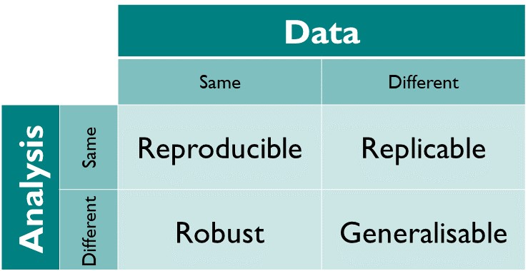

Source: [The Turing Way Community (2025)](https://book.the-turing-way.org/reproducible-research/overview/overview-definitions)

## Core tools overview

- Tools and techniques we covered:
  - Command Line (Bash): system control, automation, remote servers, containers
  - Git & GitHub: version control to track changes, revert mistakes, and collaborate
  - Quarto: literate programming, combining text, code, and results in one document
  - Cloud Computing (AWS): on-demand servers, storage, and services for scalability
- SQL & Relational Databases: structured data storage and querying with SQL
- AI Tools: programming assistants that generate, explain, and debug code
- Dask: parallel and distributed computing beyond a single machine
- Docker: containerisation, packaging apps and dependencies to run anywhere

## A quick favour 🙏

### Course evaluations are open!

- Course evaluations are now open, and I would love to hear your thoughts on the course!
- Just log on to Canvas and go to *Account → Profile → Course Evaluations*
- Works on any device: laptop, tablet, or phone
- It only takes a few minutes!
- Thank you so much for taking the time. I really appreciate it! 😊

# Computational literacy 💻

## From human computers to the silicon age

- ‘Computing’ changed a lot over time
- Originally, ‘computers’ were people doing calculations, often with tools like the abacus
- Mechanical calculators followed (e.g., Leibniz’s machine for basic arithmetic)
- The transistor, integrated circuits, and microprocessors of the silicon age gave us electronic computers
- Most modern computers use the Von Neumann architecture: program instructions and data share the same memory, accessed by a CPU

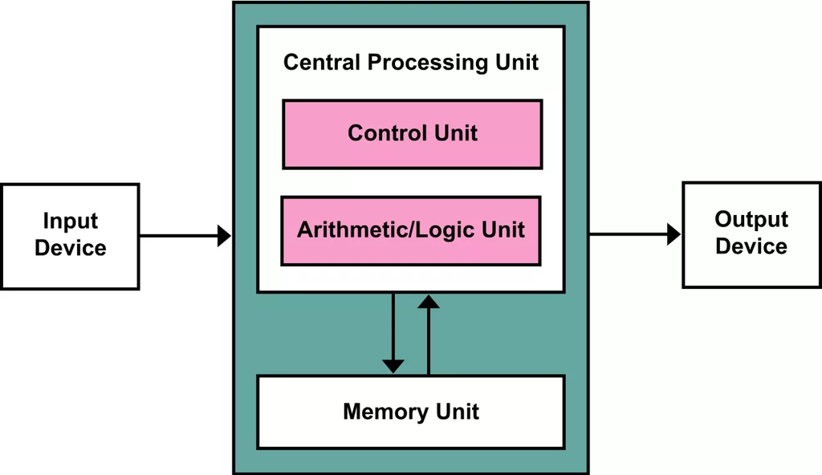

Source: [Von Neumann architecture (Wikipedia)](https://en.wikipedia.org/wiki/Von_Neumann_architecture)

## Representing data: binary, hex, and decimal

- Computers store all information in binary (base 2): only 0s and 1s
- These map to the on/off states of transistors
- One binary digit = a bit; eight bits = a byte
- Hexadecimal (base 16): digits 0-9 and A-F, shorthand for binary. Each hex digit = four bits (e.g., `FF` = `11111111` = 255)
- Used for colours (`#FF0000`) and memory addresses

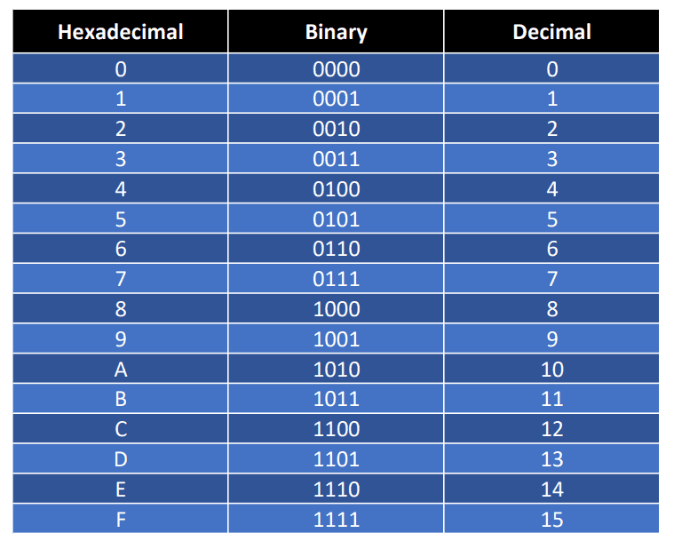

Conversion table

## Encoding information: text and images

- Computers encode information so they can process it
- Abstraction: mapping complex data types to numbers
- Digital images are grids of pixels
- Each pixel’s colour uses the RGB model: Red, Green, Blue intensities (0-255)
- Text encoding assigns a number to each character:
  - ASCII: early standard, enough for basic English but limited (7-8 bits)
  - Unicode (UTF-8): modern universal standard, supports nearly all characters (1-4 bytes)

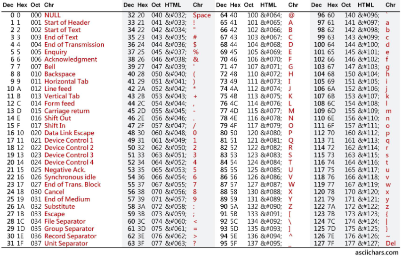

ASCII table

## Programming languages: low-level vs high-level ⌨️

Languages bridge human instructions and machine execution:

- Machine Code: raw binary the CPU runs directly
- Assembly Language: low-level mnemonics for machine instructions. CPU-specific, fine control, poor portability
- High-Level Languages (Python, R, Java): human-readable syntax, abstracts hardware. More portable, but needs translation
- Translation Methods:
  - Compiled (e.g., C++): source translated to machine code *before* running; faster execution
  - Interpreted (e.g., Python): code run line-by-line *at runtime* by an interpreter; easier development

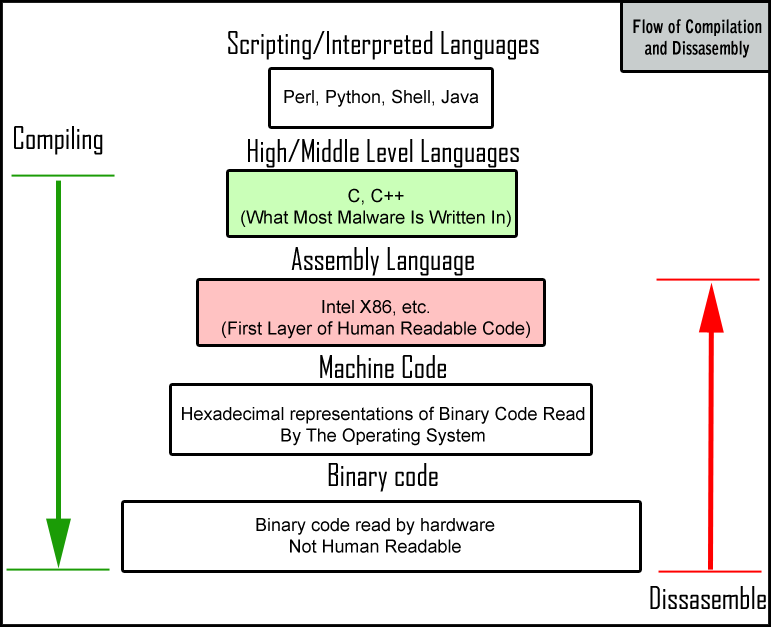

High and low-level languages

# The command line 🖥️

## Understanding the shell

- The Operating System (OS) sits between hardware and software
- Its core, the Kernel, manages hardware access and resources
- Applications run in User Space, separate from the kernel for stability
- A Shell (Bash, Zsh) is a command-line interpreter for interacting with the OS
- You access the shell through a Terminal application

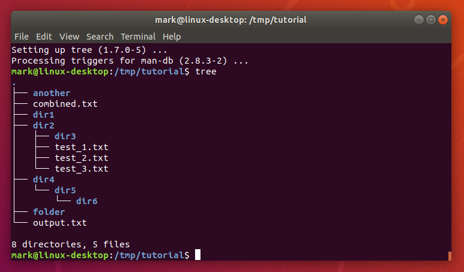

Core commands:

- `pwd`: Print Working Directory (shows current location)
- `ls`: List directory contents (`ls -l` for details, `ls -a` for hidden files)
- `cd <directory>`: Change Directory (`cd ..` up, `cd ~` home)
- `mkdir <name>`: Make Directory
- `touch <name>`: Create empty file / update timestamp
- `cp <source> <dest>`: Copy file/directory (`-r` for directories)
- `mv <source> <dest>`: Move or Rename file/directory
- `rm <file>`: Remove file (permanently!)
- `rmdir <empty_dir>`: Remove empty directory
- `rm -r <dir>`: Remove directory recursively (DANGEROUS! No undo)

## Working with text & finding files

### Inspecting and searching text:

- `cat <file>`: display entire file
- `head <file>` / `tail <file>`: first/last lines (`-n #`)
- `wc <file>`: count lines, words, characters
- `grep <pattern> <file>`: search with regular expressions
  - `-i` (ignore case), `-r` (recursive), `-n` (line numbers), `-v` (invert)

### Finding files:

- `find <path> [options]`: search tool
  - `-name <pattern>`: by name (quote patterns with `*`)
  - `-iname <pattern>`: case-insensitive
  - `-type d` / `-type f`: directories / files
  - `-size +1M`: files larger than 1 MB
- Wildcards: `*` (any characters), `?` (single character)

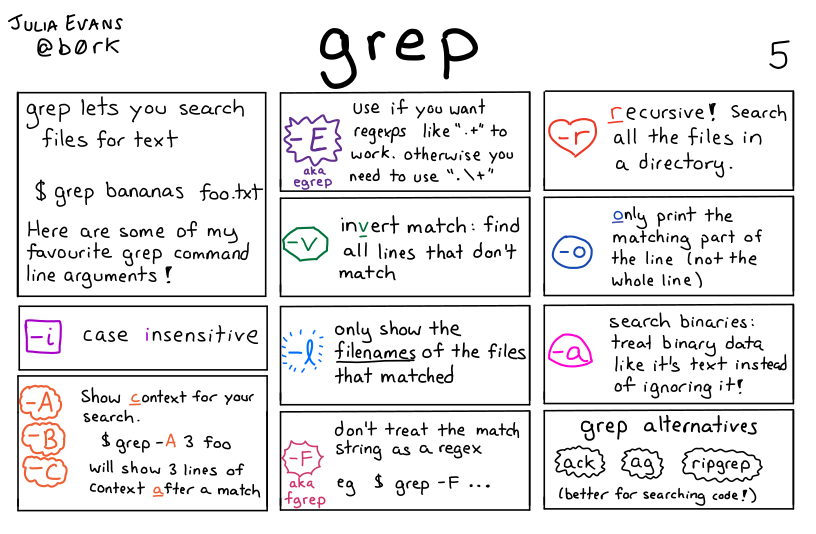

Source: [Julia Evans (2024)](https://wizardzines.com/comics/grep/)

## Pipes, redirects & scripting

- Redirection: control where output goes
  - `>`: write output to file (overwrites)
  - `>>`: append output to file
  - `<`: read input from file
- Pipes `|`: chain commands; left output becomes right input (e.g., `ls -l | grep "Jan"`)
- Shell Scripting: save commands in a `.sh` file for automation
  - Start with `#!/bin/bash` (shebang)
  - Make executable: `chmod +x script.sh`
  - Run: `./script.sh`

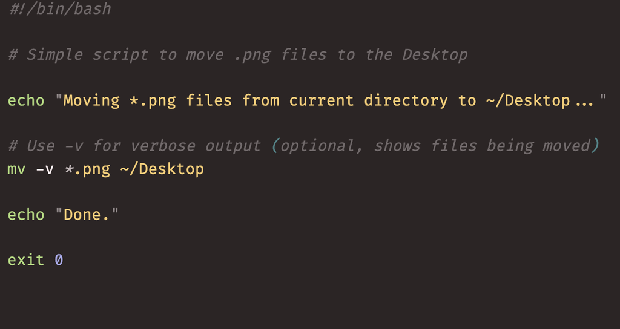

A simple script that moves `.png` files to the Desktop

# Git & GitHub 💾

## Version control basics

- Problem: managing project changes manually is chaotic 😂
- Solution: Version Control Systems (VCS) like Git track every change
- Benefits: revert to previous states, understand history, collaborate, keep backups
- Core Workflow:
  - Edit files in the Working Directory
  - Stage changes with `git add <file>` → Staging Area
  - Save a snapshot with `git commit -m "message"` → Repository
- Key commands: `git status`, `git add`, `git checkout`, `git commit`, `git diff`, `git log`, `git pull`, `git push`

[figure not shown]

Source: [Atlassian](https://www.atlassian.com/git/tutorials/comparing-workflows/gitflow-workflow)

## GitHub: collaboration platform 🤝

- GitHub: a central remote repository (`origin`) for sharing code
- Key commands:
  - `git push`: upload local commits to the remote
  - `git commit`: record changes locally
  - `git pull`: download and merge remote changes
- `.gitignore`: tells Git which files to skip
- Other GitHub features:
  - Pull Requests (code review)
  - Wikis
  - GitHub Actions (automation)
  - GitHub Pages (web hosting)

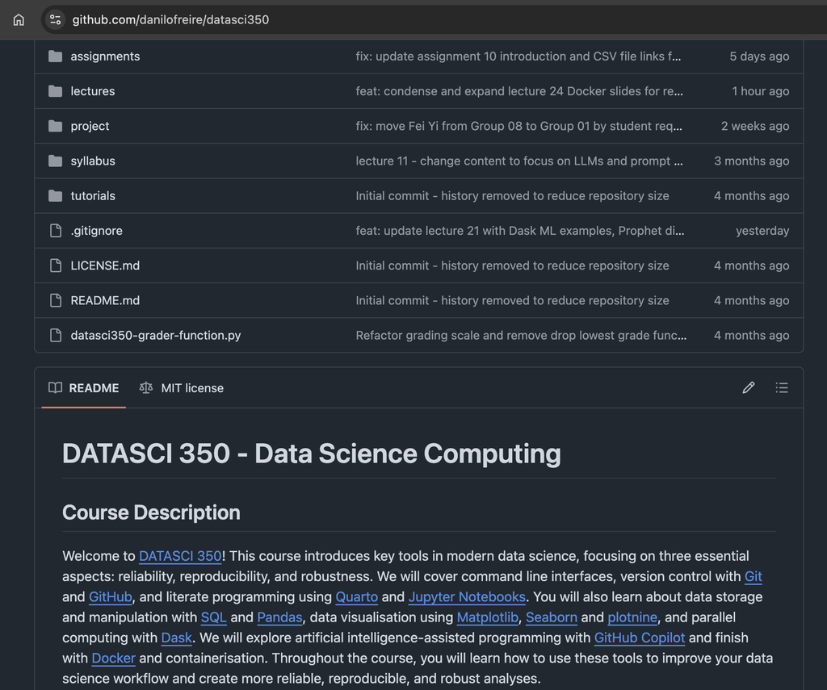

## Branching & merging 🌿

- Version control also means managing different lines of development
- Branches allow independent work without affecting `main`
- Workflow: create a branch (`git checkout -b feature-x`), commit, then merge back (`git checkout main`, `git merge feature-x`)
- Merge Conflicts: happen when branches change the same lines. Git asks you to resolve them manually
- Pull Requests (PRs): GitHub’s workflow for proposing merges with code review and discussion

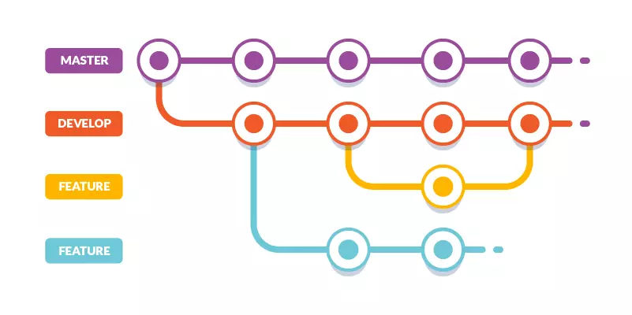

Read more: [Git Branching](https://git-scm.com/book/en/v2/Git-Branching-Branches-in-a-Nutshell)

# Quarto 📖

## Literate programming & reproducibility 💡

- Reproducible research: others can consistently reproduce your results
- Literate programming combines code, results, and narrative in one place
- Quarto: modern, open-source system built on Pandoc
- Language-agnostic: supports Python, R, Julia, Observable
- One source file (`.qmd` or `.ipynb`) → HTML, PDF, Word, slides, websites, books
- More information: [Quarto website](https://quarto.org/)

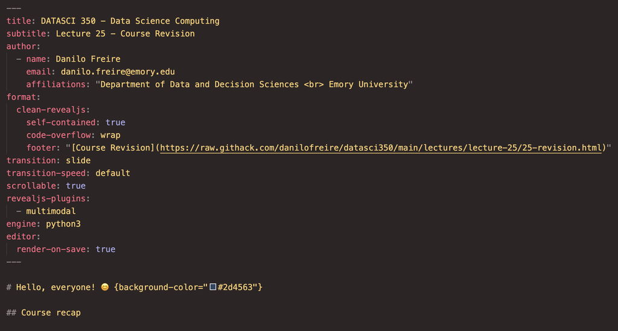

## Quarto documents

### Structure

A typical Quarto (`.qmd`) document includes:

- YAML Header: between `---` marks; sets metadata (title, author, date) and output format
- Markdown Content: narrative text with headings, lists, links, maths (`$...$`, `$$...$$`)
- Code Chunks: executable blocks (e.g., ````{python}`) with `#|` options for execution, visibility, figures, etc.
- Render with: `quarto render mydoc.qmd`

### Advanced features

You can also use Quarto for:

- Citations (`[@citekey]`, needs `.bib`)
- Cross-references (`@fig-label`)
- Callouts, Tabsets
- Interactive components
- Websites, Books, Presentations

# AI-assisted programming 🤖

## LLMs & code generation

- LLMs (Large Language Models) like GPT-4 and Claude: trained on vast text/code data to generate code, explain concepts, translate languages
- AI-Assisted Programming: using LLMs as coding companions (GitHub Copilot, ChatGPT)
- Benefits: faster development, less repetitive coding, help with debugging and learning
- Risks: hallucinations (incorrect/insecure code), training data biases, IP concerns
- Good prompt engineering matters: clear instructions, context, examples
- Agents: LLMs that act autonomously (web browsing, API calls)

[figure not shown]

WebUI GitHub repository: https://github.com/browser-use/web-ui

# Cloud computing ☁️

## What is cloud computing? 🤔

- IaaS (Infrastructure as a Service): virtual machines (EC2), networks. You manage the rest
- PaaS (Platform as a Service): develop and run apps without managing servers or OS
- SaaS (Software as a Service): complete applications delivered over the internet
- FaaS (Function as a Service / Serverless): run code on events, no server management (AWS Lambda, Google Cloud Functions)
- EC2 (Elastic Compute Cloud): scalable virtual servers (instances)
  - Pick an AMI (Amazon Machine Image) to launch
  - Instance types: different CPU, RAM, storage configs
  - Choose OS, instance type, storage (EBS). Connect via SSH
- S3 (Simple Storage Service): scalable object storage in buckets
- RDS (Relational Database Service): managed relational databases (PostgreSQL, MySQL, etc.)
- SageMaker: build, train, and deploy ML models
- Cost Management: set up billing alarms!

## Interacting with EC2 instances

- Launching: in the AWS Console, pick AMI, instance type, storage, security groups, and an SSH key pair (`.pem` file)
- Connecting (SSH): use `ssh` with your `.pem` key (set `chmod 400 key.pem` first)
  - `ssh -i key.pem ubuntu@<public-ip-or-dns>`
- Managing Software (Ubuntu): `apt` package manager
  - `sudo apt update` → refresh package lists
  - `sudo apt upgrade` → install updates
  - `sudo apt install <package-name>` → install software
- Transferring Files (`scp`): copy files to/from EC2
  - `scp -i key.pem local_file ubuntu@ip:/remote/path` (local → remote)
  - `scp -i key.pem ubuntu@ip:/remote/file ./local/path` (remote → local)
- Stopping/Terminating: Stop = pause (still pay for storage); Terminate = delete permanently. Manage costs!

# Python and SQL for data science 🐍 🗄️

## Relational databases & SQL

- Relational Databases: structured tables with defined relationships (PostgreSQL, MySQL, SQLite)
- SQL: standard language for querying and managing these databases
- SQLite: file-based, serverless database engine
- Keys:
  - Primary Key (PK): uniquely identifies each row
  - Foreign Key (FK): references a PK in another table, creating links

Core commands:

- `CREATE TABLE`: Define table schema (columns, data types like `INTEGER`, `TEXT`, `REAL`)
- `INSERT INTO`: Add new rows
- `SELECT`: Retrieve data (`SELECT cols FROM table WHERE condition ORDER BY col`)
- `UPDATE`: Modify existing rows (`UPDATE table SET col = val WHERE condition`)
- `DELETE FROM`: Remove rows (`DELETE FROM table WHERE condition`)
- `ALTER TABLE`: Modify table structure
- `DROP TABLE`: Delete a table

## Advanced SQL

Going beyond basic queries:

- Filtering (`WHERE`): operators (`=`, `>`, `LIKE`, `IN`, `BETWEEN`, `IS NULL`) + logic (`AND`, `OR`)
- Aggregation (`GROUP BY`): group rows, apply functions (`COUNT`, `SUM`, `AVG`); filter with `HAVING`
- Joins: combine tables (`INNER JOIN`, `LEFT JOIN`) on related columns
- Subqueries: nested `SELECT` statements
- Window Functions: calculations across related rows (`RANK() OVER (...)`, `AVG(...) OVER (PARTITION BY ...)`), keeping individual rows
- String Functions: `SUBSTR`, `LENGTH`, `REPLACE`, `||` (concatenation)
- Conditional Logic: `CASE WHEN condition THEN result ... ELSE default END`
- Python’s `sqlite3` module: connect, cursor, execute, commit, fetch, close
- Pandas makes it simpler:
  - `pd.read_sql(query, conn)`: query → DataFrame
  - `df.to_sql('table', conn, ...)`: DataFrame → database table

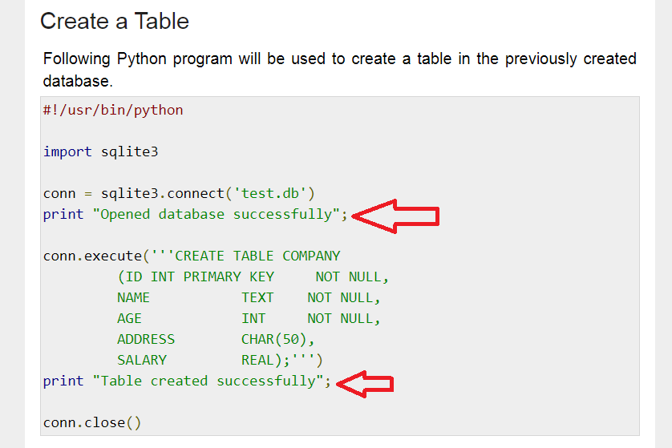

# Parallel computing ⚡

## Serial vs parallel

- Serial: tasks run one after another; slow for large workloads
- Parallel: tasks run concurrently on multiple cores/machines
- Best for “embarrassingly parallel” problems (independent computations)
- Python Libraries:
  - `joblib`: simple single-machine parallelism (`Parallel`, `delayed`)
  - `dask`: scalable parallel/distributed computing

### Dask:

- Dask Array: parallel NumPy arrays
- Dask DataFrame: parallel Pandas DataFrames
- Dask Delayed: parallelise custom functions
- Dask Distributed: cluster management (multi-process/multi-machine)

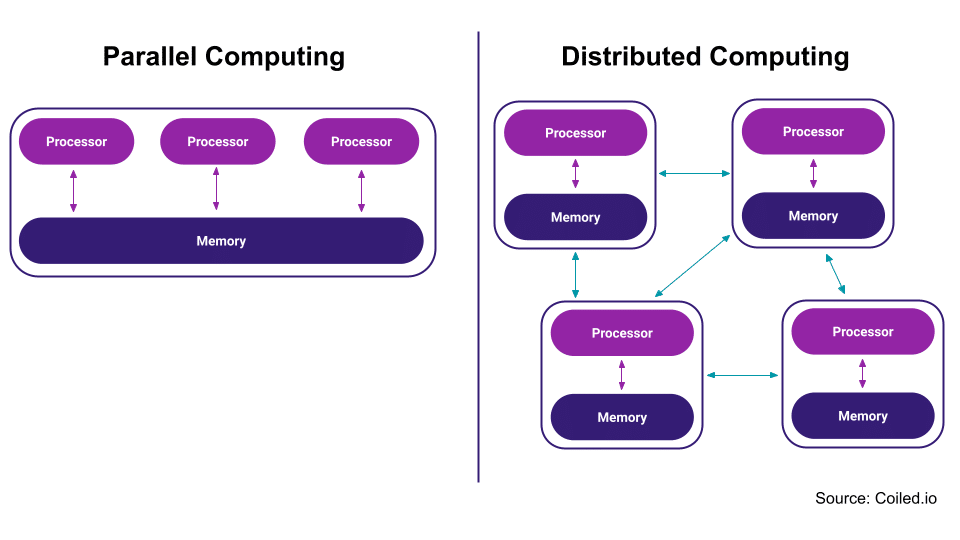

[figure not shown]

# Containers & Docker 🐳

## Dependency management & reproducibility

### Virtual environments

- Challenge: “it works on my machine” problem, where code fails elsewhere because of different dependencies
- Solution: explicitly manage dependencies for reproducibility
- Virtual Environments (`venv`, `conda`): isolate project packages, prevent conflicts
  - Define with `requirements.txt` (pip) or `environment.yml` (conda)
- Limitation: virtual environments only isolate Python packages, not system libraries

### Containers

- Containers: package an app with *all* its dependencies (system libs, tools, code, runtime) in one portable unit
- Runs the same way on any machine with Docker
- Docker Concepts:
  - Image: immutable template built from a Dockerfile
  - Container: running instance of an image
  - Dockerfile: instructions (`FROM`, `RUN`, `COPY`, etc.) to build the image
  - Registry (e.g., Docker Hub): stores and shares images

## Using Docker

Basic workflow:

- Write Dockerfile: define base OS, packages, code, run command
- Build Image: `docker build -t myimage:latest .`
- Run Container: `docker run -p 8888:8888 -v $(pwd):/app myimage:latest`
  - `-p`: port mapping (host:container)
  - `-v`: volume mount (host:container) for persistent data
  - `-it`: interactive terminal
- Share: `docker push` / `docker pull` (via Docker Hub or other registry)

```
FROM ubuntu:24.04

RUN apt-get update && \
    apt-get install -y python3 python3-pip && \
    apt-get clean && \
    rm -rf /var/lib/apt/lists/*

RUN python3 --version
RUN pip3 --version

CMD ["python3"]

COPY . /app
WORKDIR /app
RUN pip3 install -r requirements.txt
CMD ["python3", "your_script.py"]
```

Example Dockerfile

# Conclusion 🎓

## What we learnt

- Computational literacy, reproducibility, and solid data science practices
- Command line, version control (Git & GitHub), reproducible reports (Quarto)
- Data manipulation with Python/Pandas and database queries with SQL
- AI-assisted programming, parallel computing (Dask), and containers (Docker)

[figure not shown]

# Questions? 🤔

# Thank you very much! 🙏